# Visualisation with R (examples from The Book of R)

## Smoothing and Shading

### LOESS

A non-parametric smoothing method can provide an idea of general trends in the data without requiring a model to be fitted. A common method is LOESS or LOWESS (Locally Weighted Scatterplot Smoothing), which ggplot2 implements and for which it provides a simple invocation mechanism.

To illustrate the creation of a smoothed trend curve with ggplot2 we will use the survey data from the MASS package. First we prepare the data by removing missing values. Then we plot `Height` against `Wr.Hnd` and include a smoothed trend curve, with a 95% confidence interval shaded around it.

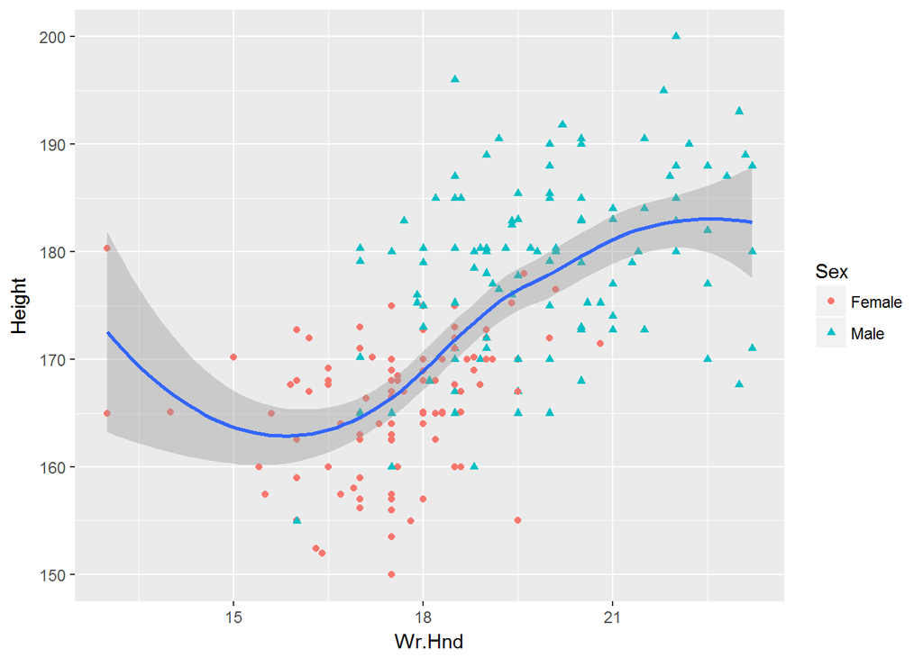

```r
surv <- na.omit(survey[,c("Sex", "Wr.Hnd", "Height")])
ggplot(surv, aes(x=Wr.Hnd, y=Height)) +
   geom_point(aes(col=Sex, shape=Sex)) +
   geom_smooth(method="loess")
```

The effort in base R required to produce the same plot is considerably greater.

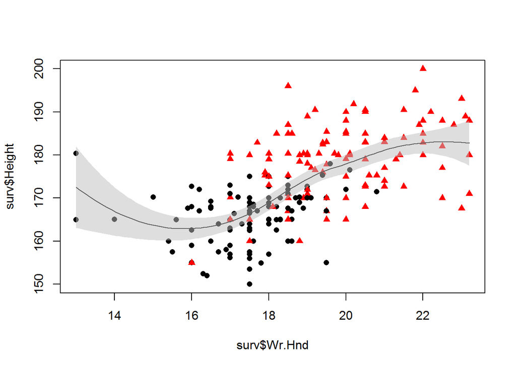

```r
plot(surv$Wr.Hnd, surv$Height, col=surv$Sex, pch=c(16, 17)[surv$Sex])
smoother <- loess(Height~Wr.Hnd, data=surv)
handseq <- seq(min(surv$Wr.Hnd), max(surv$Wr.Hnd), length=100)
sm <- predict(smoother, newdata=data.frame(Wr.Hnd=handseq), se=TRUE)
lines(handseq, sm$fit)
polygon(x=c(handseq, rev(handseq)), y=c(sm$fit+2*sm$se, rev(sm$fit-2*sm$se)), col=adjustcolor("gray", alpha.f=0.5), border=NA)
```

The power of the ggplot2 version of the code is even more pronounced in the code for producing separate LOESS curves for the sexes.

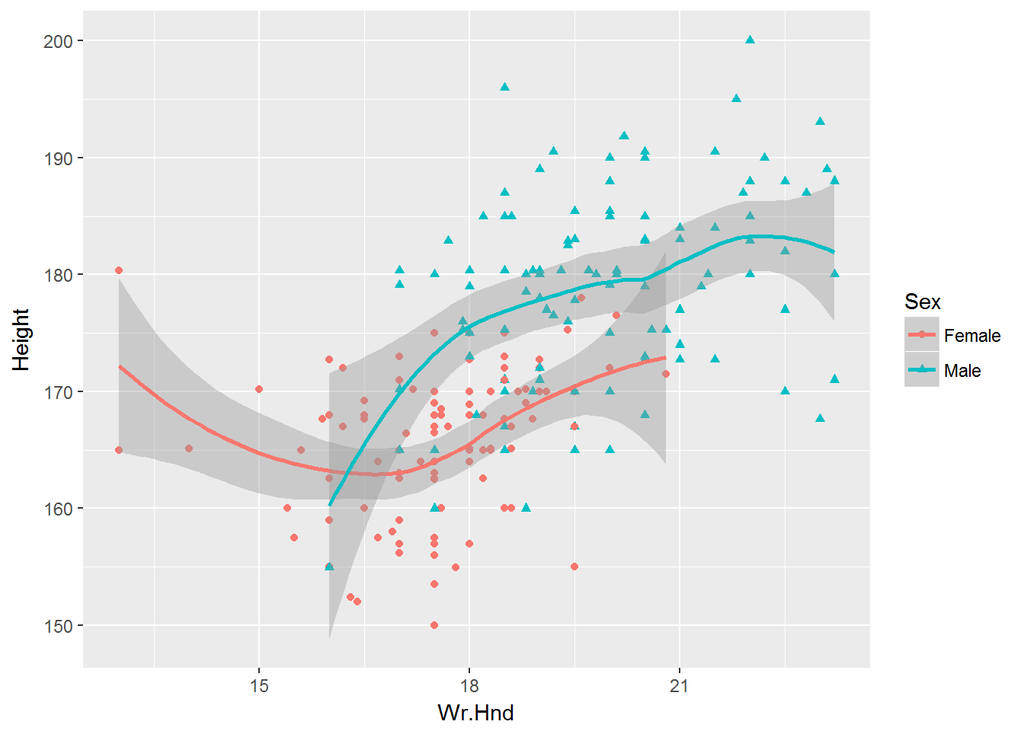

```r
ggplot(surv, aes(x=Wr.Hnd, y=Height, col=Sex, shape=Sex)) + geom_point() + geom_smooth(method="loess")
```

The `span` parameter is used to specify the proportion of the data used in each step of the localised estimation procedure. The default value is 0.75.

We recreate the first of the loess plots twice more, with different values for this parameter.

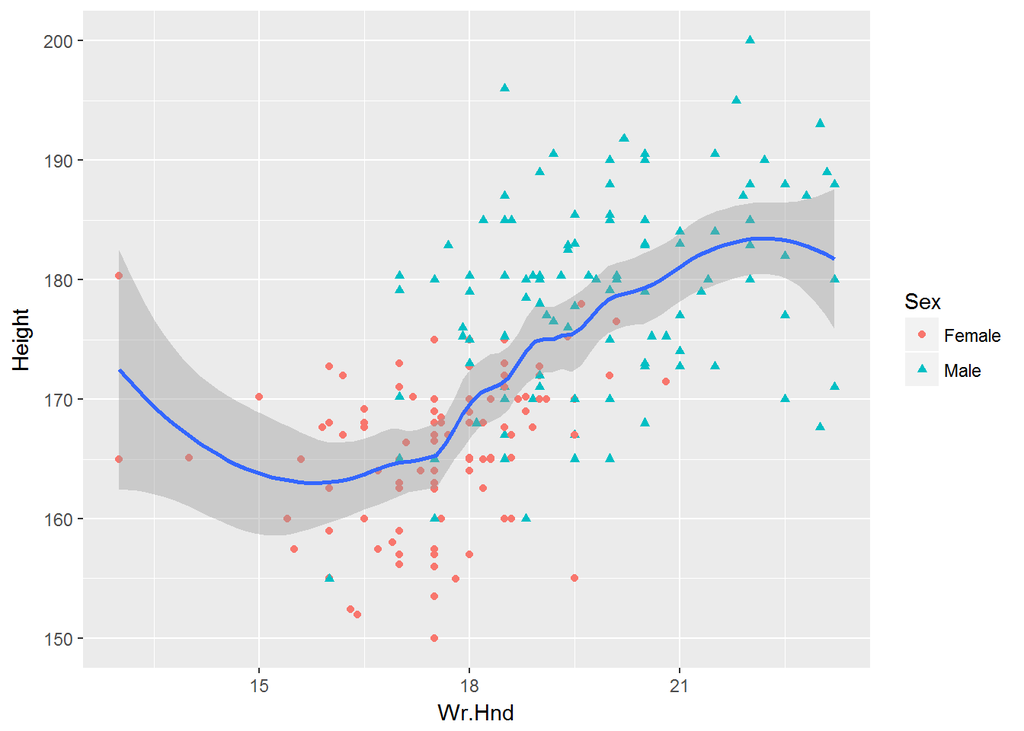

```r
ggplot(surv, aes(x=Wr.Hnd, y=Height)) +
   geom_point(aes(col=Sex, shape=Sex)) +
   geom_smooth(method="loess", span=0.4)
```

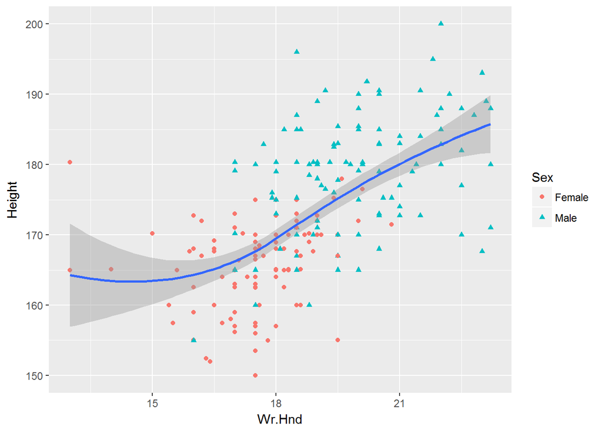

```r
ggplot(surv, aes(x=Wr.Hnd, y=Height)) +
   geom_point(aes(col=Sex, shape=Sex)) +
   geom_smooth(method="loess", span=1.5)
```

### KDE

Kernel density estimation (KDE) is a method for producing a smooth estimate of a probability density function based on observed data.

The following will plot an estimate of the probability density function for the `airquality` data variable `Temp`.

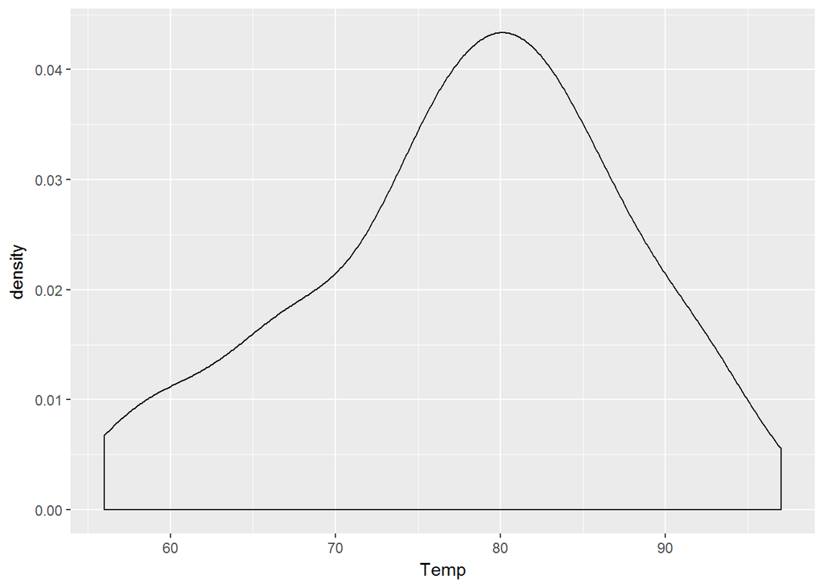

```r
ggplot(data=airquality, aes(x=Temp)) + geom_density()
```

Now we create a plot with separate estimated probability density functions for the different months that feature in the data.

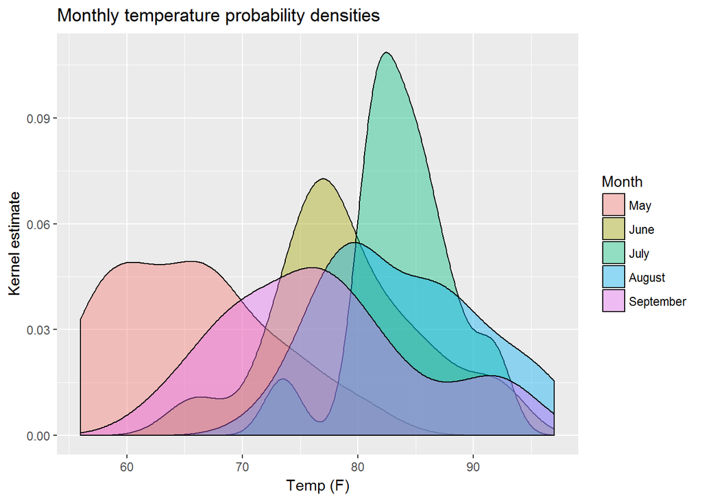

```r
air <- airquality
air$Month <- factor(air$Month, labels=c("May", "June", "July", "August", "September"))
ggplot(data=air, aes(x=Temp, fill=Month)) +
   geom_density(alpha=0.4) +
   ggtitle("Monthly temperature probability densities") +
   labs(x="Temp (F)", y="Kernel estimate")
```

## Multiple Plots and Variable-Mapped Facets

The functions in ggplot2 do not work with `mfrow` and `layout()`, but there are other mechanisms that can be used for placing multiple plots on one device with ggplot2.

A quick way of arranging **multiple independent plots in a single image** is with the function `grid.arrange` from the **gridExtra** package.

To illustrate the use of this package we re-use the `air` object we created earlier and define three ggplot objects.

```r
gg1 <- ggplot(air, aes(x=1:nrow(air), y=Temp)) +
   geom_line(aes(col=Month)) +
   geom_point(aes(col=Month, size=Wind)) +
   geom_smooth(method="loess", col="Black") +
               labs(x="Time (days)", y="Temperature (F)")
gg2 <- ggplot(air, aes(x=Solar.R, fill=Month)) +
   geom_density(alpha=0.4) +
   labs(x=expression(paste("Solar radiation (", ring(A),")")), y="Kernel estimate")
gg3 <- ggplot(air, aes(x=Wind, y=Temp, color=Month)) +
   geom_point(aes(size=Ozone)) +
   geom_smooth(method="lm", level=0.9, fullrange=FALSE, alpha=0.2) +
   labs(x="Wind speed (MPH)", y="Temperature (F)")
```

Now, after including the gridExtra package in our library (the package must be installed beforehand), we can call the function `grid.arrange()` to display all three plots combined into a single image.

```r
library("gridExtra")
```

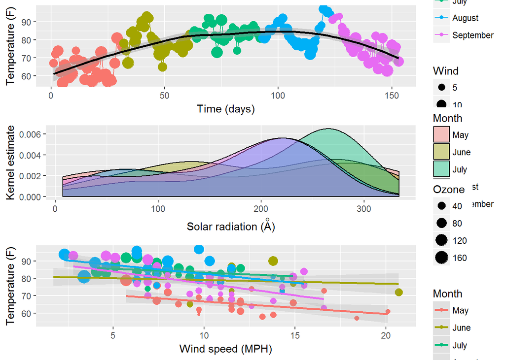

```r
grid.arrange(gg1, gg2, gg3)
```

In the case that faceting is required i.e. the creation of **several plots** of the same variables, distinguished **by values of one or more categorical variables**, the functions to use are `facet_wrap()` and `facet_grid()`.

Let’s use the temperature plot produced earlier:

```r
ggp <- ggplot(data=air, aes(x=Temp, fill=Month)) +
   geom_density(alpha=0.4) +
   ggtitle("Monthly temperature probability densities") +
   labs(x="Temp (F)", y="Kernel estimate")
```

We can separate the plots for different months in the following way:

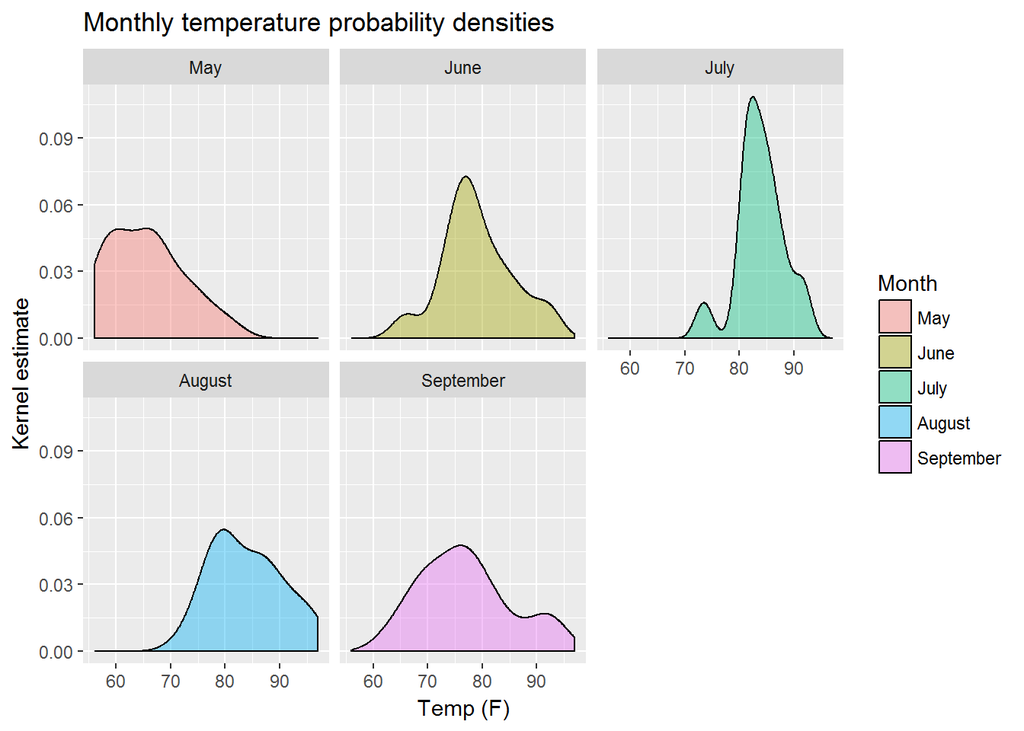

```r
ggp + facet_wrap(~Month)
```

Specifying `scales="free"` scales the plots individually (only one axis can be made free by using `scales="free_x"` or `scales="free_y"`)

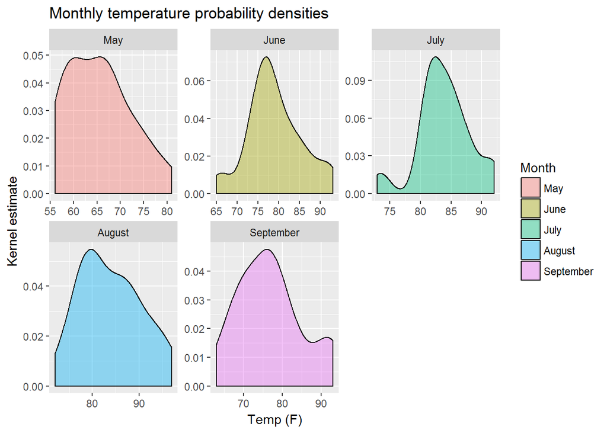

```r
ggp + facet_wrap(~Month, scales="free")
```

Another parameter is `nrow`:

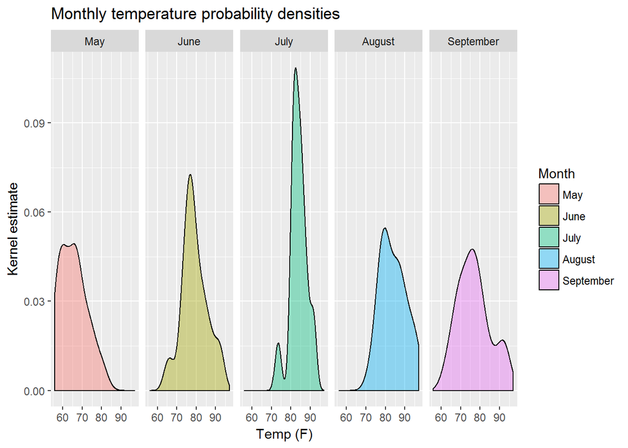

```r
ggp + facet_wrap(~Month, nrow=1)
```

The function `facet_grid` works with two faceting variables, one’s values changing between rows and the others’ between columns. These are specified in the format `var1~var2` and if only one variable is used the other can be replaced with a dot.

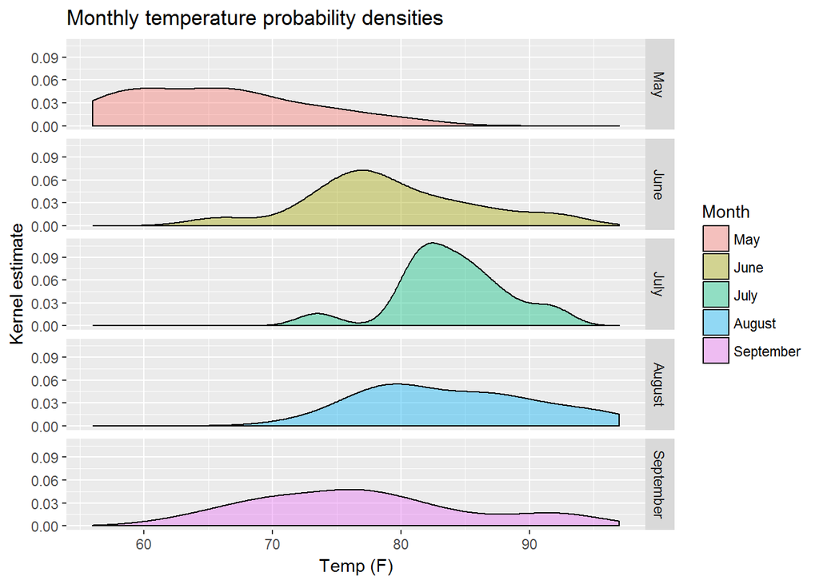

```r
ggp + facet_grid(Month~.)
```

To demonstate the use of `facet_grid()` with two variables, we use the dataset `mpg` found in the ggplot2 package.

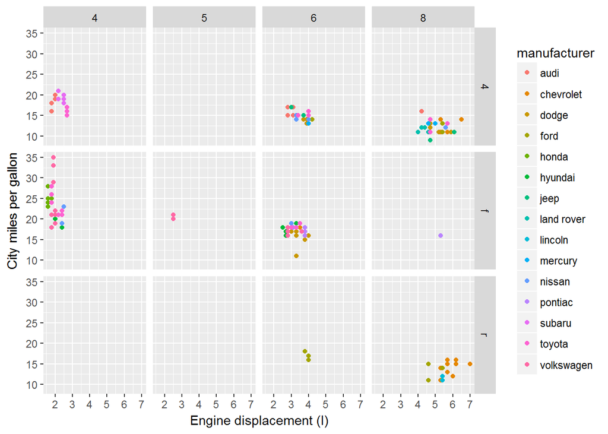

```r
ggplot(ggplot2::mpg, aes(x=displ, y=cty)) + geom_point(aes(col=manufacturer)) +
   labs(x="Engine displacement (l)", y="City miles per gallon") +
   facet_grid(drv~cyl)
```

## Interactive plots

The package **ggvis** can create interactive plots.

The ggvis package uses the pipe operator `%>%` rather than a `+` to chain commands and its drawing function names start with `layer_` rather than `geom_` but otherwise operates similarly to ggplot2.

Let’s prepare some data from the `survey` dataset in the MASS package.

```r
library("MASS")
surv <- na.omit(survey[, c("Sex", "Wr.Hnd", "Height", "Smoke", "Exer")])
```

Now lets create our first plot with ggvis. The ‘tilda’ character as a prefix to a variable name indicates that the variable is from the dataframe.

```r
library("ggvis")
```

```r
surv %>% ggvis(x=~Height) %>% layer_histograms()
```

```
## Guessing width = 2 # range / 25
```

The plot is produced in the form of web graphics. Notice the ‘cog’ symbol that is included with the plot and which allows you a minimal amount of general interaction with the plot.

Now we go a bit further with the following line of code. The assignment operator `:=` is used instead of `=` where a fixed value is being passed in, rather than a value subject to change, rather like an aesthetic mapping in ggplot.

```r
surv %>% ggvis(x=~Height) %>% layer_histograms(width=input_slider(1, 15, label="Binwidth:"), fill:="gray")
```

Because the output of ggvis is web-based, it is not included in the notebook but shown in the RStudio viewer. The slider in the output pane allows us to change the bin width of the displayed histogram.

Other kinds of controls can be included in the plot. Let’s try another example, starting with a basic plot.

```r
surv %>% ggvis(x=~Wr.Hnd, y=~Height, size:=200, opacity:=0.3) %>% layer_points()
```

To this we can add controls.

```r
filler <- input_radiobuttons(c("Sex"="Sex", "Smoking status"="Smoke", "Exercise frequency"="Exer"), map=as.name, label="Color points by...")
sizer <- input_slider(10, 300, label="Point size:")
opacityer <- input_slider(0.1, 1, label="opacity:")
surv %>% ggvis(x=~Wr.Hnd, y=~Height, fill=filler, size:=sizer, opacity:=opacityer) %>% layer_points() %>%
   add_axis("x", title="Handspan") %>% add_legend("fill", title="")
```

Finally, an example where a slider is used to change the span of a smoothed trend curve.

```r
surv %>% ggvis(x=~Wr.Hnd, y=~Height, fill=~Sex) %>% group_by(Sex) %>%
   layer_smooths(span=input_slider(0.3, 1, value=0.75, label="Smoothing span:"), se=TRUE) %>%
   layer_points() %>% add_axis("x", title="Handspan")
```

# Colour

## Representing colours

The strings representing the **8 colours of the R default palette** are:

```r
palette()
```

```
## [1] "black"   "red"     "green3"  "blue"    "cyan"    "magenta" "yellow"
## [8] "gray"
```

These strings, or numbers from 1 to 8, can be used to specify the 8 colours.

The **RGB components** (saturations or intensities) of a colour are returned by function `col2rgb()`. The function takes a vector of colours and returns the red, green and blue intensities (**RGB triplet**) for each colour in the vector.

```r
col2rgb(c("black", "green3", "pink"))
```

```
##       [,1] [,2] [,3]
## red      0    0  255
## green    0  205  192
## blue     0    0  203
```

A colour can also be represented with a hexadecimal number. The function `rgb()` converts RGB triplets into these hexadecimal values.

```r
rgb(t(col2rgb(c("black", "green3", "pink"))), maxColorValue=255)
```

```
## [1] "#000000" "#00CD00" "#FFC0CB"
```

The following function plots points in different colours, with RGB triplet and hexadecimal labels. We call the function with a vector of 14 colours.

```r
pcol <- function(cols) {
   n <- length(cols)
   dev.new(width=7, height=7)
   par(mar=rep(1,4))
   plot(1:5, 1:5, type="n", xaxt="n", yaxt="n", ann=FALSE)
   for (i in 1:n) {
      pt <- locator(1)
      rgbval <- col2rgb(cols[i])
      points(pt, cex=4, pch=19, col=cols[i])
      text(pt$x+1, pt$y, family="mono",
           label=paste("\"", cols[i], "\"", "\nR: ", rgbval[1], " G: ", rgbval[2], " B: ", rgbval[3],
                       "\nhex: ", rgb(t(rgbval), maxColorValue=255), sep=""))
   }
}
mycols <- c("black", "blue", "royalblue2", "pink", "magenta", "purple", "violet", "coral", "lightgray", "seagreen4", "red", "red2", "yellow", "lemonchiffon3")
```

Now we can call `pcol(mcols)` (from the console) and click on 14 points to tell the function where to place information about the 14 colours. Note that this will not work from the R notebook.

## Palettes

There are a number of built-in palettes in R. Vectors of equally spaced colours are returned by pallete functions that take the number of required colours as a parameter. The exception is the function `gray()` which takes a vector parameter containing the required levels of gray, specified using numbers between 0 (total black) and 1 (tatal white).

```r
N <- 600
rbow <- rainbow(N)
heat <- heat.colors(N)
terr <- terrain.colors(N)
topo <- topo.colors(N)
cm <-cm.colors(N)
gry1 <- gray.colors(N)
gry2 <- gray(level=seq(0, 1, length=N))
```

Now we visualise the colour vectors created from the palettes.

```r
dev.new(width=8, height=3)
par(mar=c(1, 8, 1, 1))
plot(1, 1, xlim=c(1, N), ylim=c(0.2, 7.5), type="n", xaxt="n", yaxt="n", ann=FALSE)
points(rep(1:N, 7), rep(7:1, each=N), pch=19, cex=3, col=c(rbow, heat, terr, topo, cm, gry1, gry2))
axis(2, at=7:1, labels=c("rainbow", "heat.colors", "terrain.colors", "topo.colors", "cm.colors", "gray.colors", "gray"), family="mono", las=1)
```

The function `colorRampPalette()` creates a palette function like the ones used above, from colours passed in as parameters.

```r
puryel.colors <- colorRampPalette(colors=c("purple", "yellow"))
blues <- colorRampPalette(colors=c("navyblue", "lightblue"))
fours <- colorRampPalette(colors=c("black", "hotpink", "seagreen4", "tomato"))
irish.flag <- colorRampPalette(colors=c("green", "white", "orange"))
```

Now we repeat the plot above but with our custom palettes.

```r
py <- puryel.colors(N)
bls <- blues(N)
frs <- fours(N)
irl <- irish.flag(N)
dev.new(width=8, height=2)

par(mar=c(1, 8, 1, 1))
plot(1, 1, xlim=c(1, N), ylim=c(0.2, 4.5), type="n", xaxt="n", yaxt="n", ann=FALSE)
points(rep(1:N, 4), rep(4:1, each=N), pch=19, cex=3, col=c(py, bls, frs, irl))
axis(2, at=4:1, labels=c("puryel.colors", "blues", "fours", "irish.flag"), family="mono", las=1)
```

## Using colours to represent continuous variables

There are two ways of doing this. One way is to **turn the continuous variable into a categorical one, then use discrete colours to index the categorical variable**.

We use the `survey` data from the MASS package again. We alsocreate a custom palette function and ‘categorise’ the variable `surv$NW.Hnd`. We prepare the colours for the plot. Finally, we plot using two other variables for x and y.

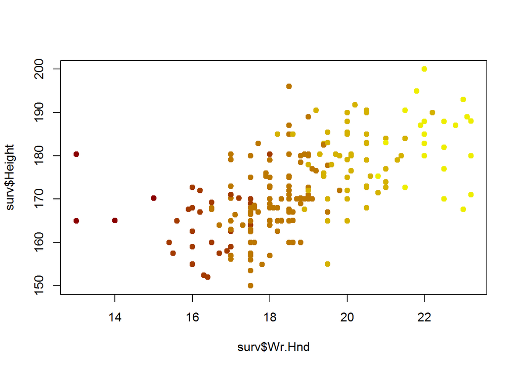

```r
surv <- na.omit(survey[, c("Wr.Hnd", "NW.Hnd", "Height")])
# create palette
NW.pal <- colorRampPalette(colors=c("red4", "yellow2"))
k <- 5
# categorisation of surv$NW.Hnd
NW.fac <- cut(surv$NW.Hnd, breaks=seq(min(surv$NW.Hnd), max(surv$NW.Hnd), length=k+1), include.lowest=TRUE)
# colour vector with a colour for each point
NW.cols <- NW.pal(k)[as.numeric(NW.fac)]
#plot
plot(surv$Wr.Hnd, surv$Height, col=NW.cols, pch=19)
```

The other way of representing a continuous variable with colour is **via normalisation**. First, we write a function to normalize the values of the continuous variable to the range (0,1).

```r
normalize <- function (datavec) {
   lo <- min(datavec, na.rm=TRUE)
   up <- max(datavec, na.rm=TRUE)
   datanorm <- (datavec-lo)/(up-lo)
   return(datanorm)
}
```

The function we need now is `colorRamp()`. It creates a function that takes a vector parameter containing the required colour levels, specified using numbers between 0 and 1 (like the function `gray()` used earlier). The colours returned by the created function are in RGB triplets and must be converted using `rgb()` to hexadecimal before they can be used in `plot()`. Once the colours are prepared, the plot is straightforward.

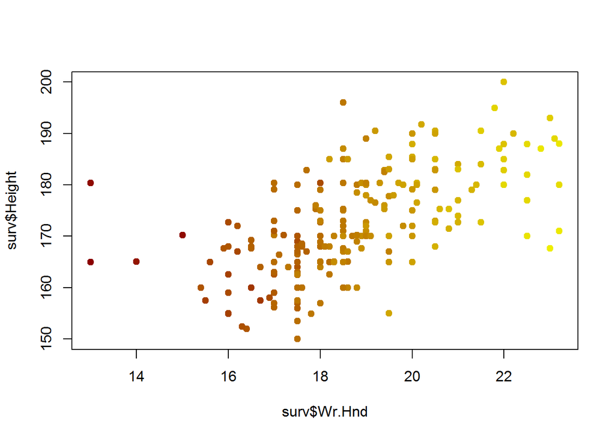

```r
NW.pal2 <- colorRamp(colors=c("red4", "yellow2"))
NW.cols2 <- rgb(NW.pal2(normalize(surv$NW.Hnd)), maxColorValue=255)
plot(surv$Wr.Hnd, surv$Height, col=NW.cols2, pch=19)
```

While in this example the difference is not noticeable, the normalization method is to be given preferrence, as it better correpsonds to the continuous nature of the variable that is represented.

## Color legends

Colour legends can be created with function `colorlegend()` from library `shape`.

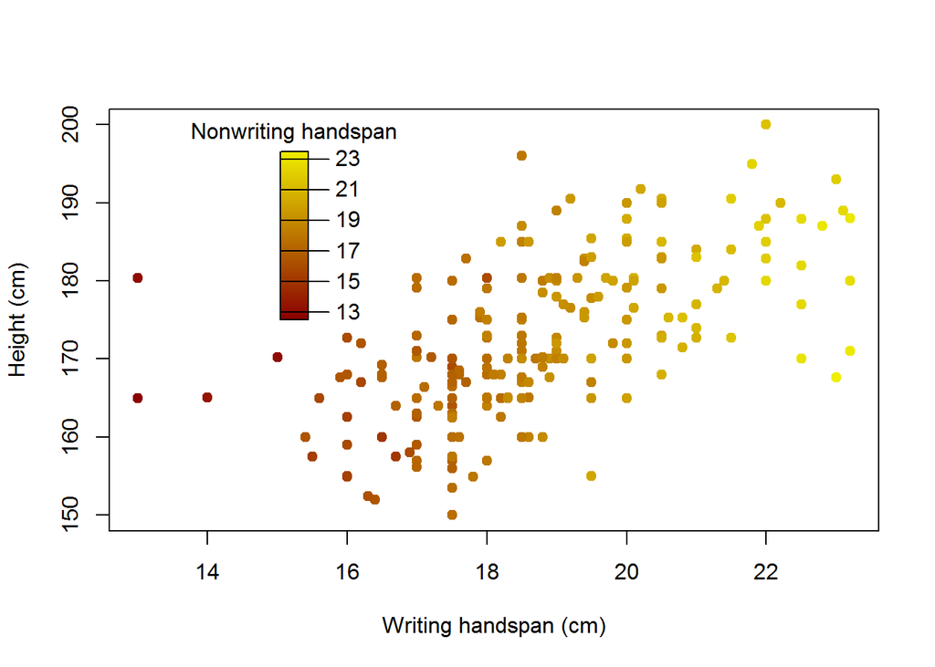

```r
library("shape")
plot(surv$Wr.Hnd, surv$Height, col=NW.cols2, pch=19, xlab="Writing handspan (cm)", ylab="Height (cm)")
colorlegend(NW.pal(200), zlim=range(surv$NW.Hnd), zval=seq(13, 23, by=2), posx=c(0.3, 0.33), posy=c(0.5, 0.9), main="Nonwriting handspan")
```

Now a call with slightly different parameters, placing the legend in the margin.

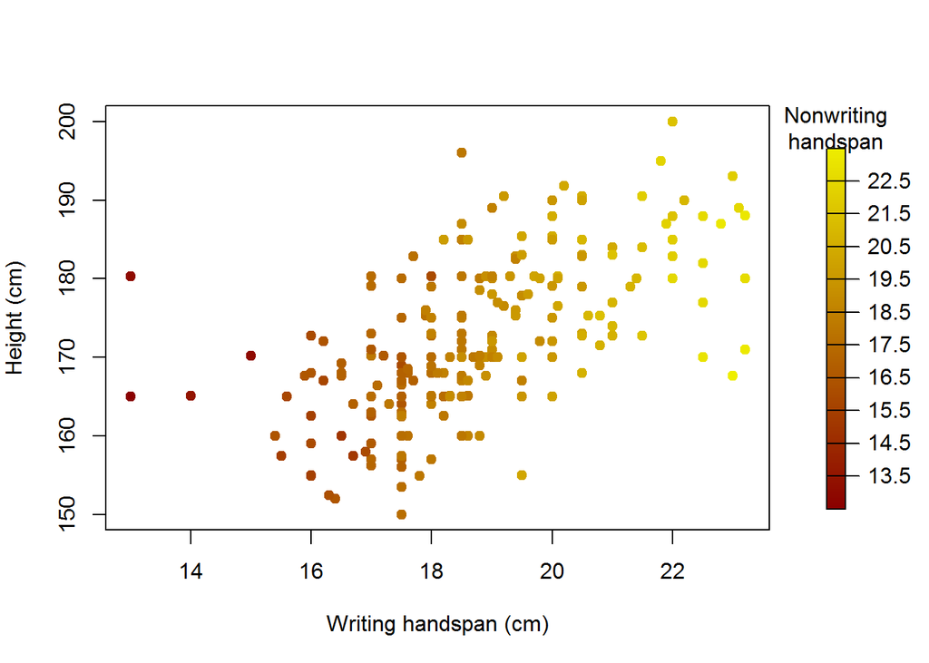

```r
par(mar=c(5, 4, 4, 6))
plot(surv$Wr.Hnd, surv$Height, col=NW.cols2, pch=19, xlab="Writing handspan (cm)", ylab="Height (cm)")
colorlegend(NW.pal(200), zlim=range(surv$NW.Hnd), zval=13.5:22.5, digit=1, posx=c(0.89, 0.91), main="Nonwriting\nhandspan")
```

## Opacity

We can add an opacity parameter, alpha, into the colour functions.

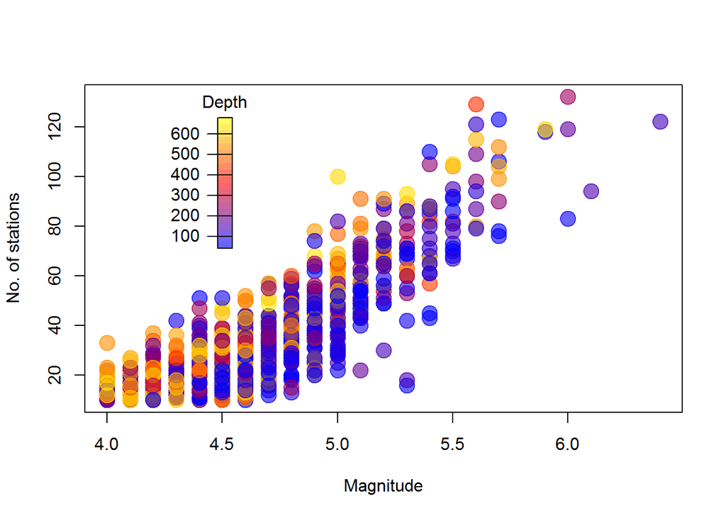

```r
keycols <- c("blue", "red", "yellow")
depth.pal <- colorRampPalette(keycols)
depth.pal2 <- colorRamp(keycols)

depth.cols <- rgb(depth.pal2(normalize(quakes$depth)), maxColorValue=255, alpha=0.6*255)

plot(quakes$mag, quakes$stations, pch=19, cex=2, col=depth.cols, xlab="Magnitude", ylab="No. of stations")
colorlegend(adjustcolor(depth.pal(20), alpha.f=0.6), zlim=range(quakes$depth), zval=seq(100, 600, 100),
            posx=c(0.3, 0.32), posy=c(0.5, 0.9), left=TRUE, main="Depth")
```

## Other colour functionality

Other colour formats are supported:

- hue-saturation-value (HSV) - function `hsv()`
- hue-chroma-luminance (HCL) - function `hcl()`

Useful colour packages:

- colorspace - for converting between formats
- RColorBrewer - more options for creating palettes

# Showing the third dimension

## Basic plots

The most common method for this is the `scatterplot3d()` function from the package by the same name.

The following example uses the `iris` data set.

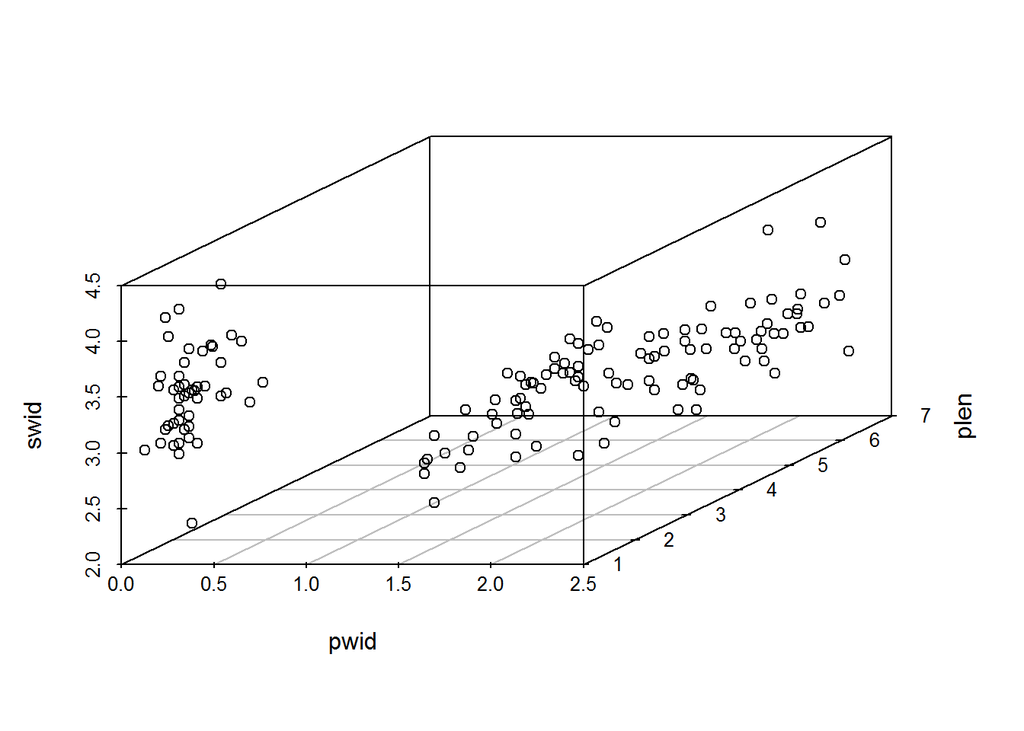

```r
pwid <- iris$Petal.Width
plen <- iris$Petal.Length
swid <- iris$Sepal.Width
slen <- iris$Sepal.Length

library("scatterplot3d")
scatterplot3d(x=pwid, y=plen, z=swid)
```

The same plot with some enhancements for better perception of depth:

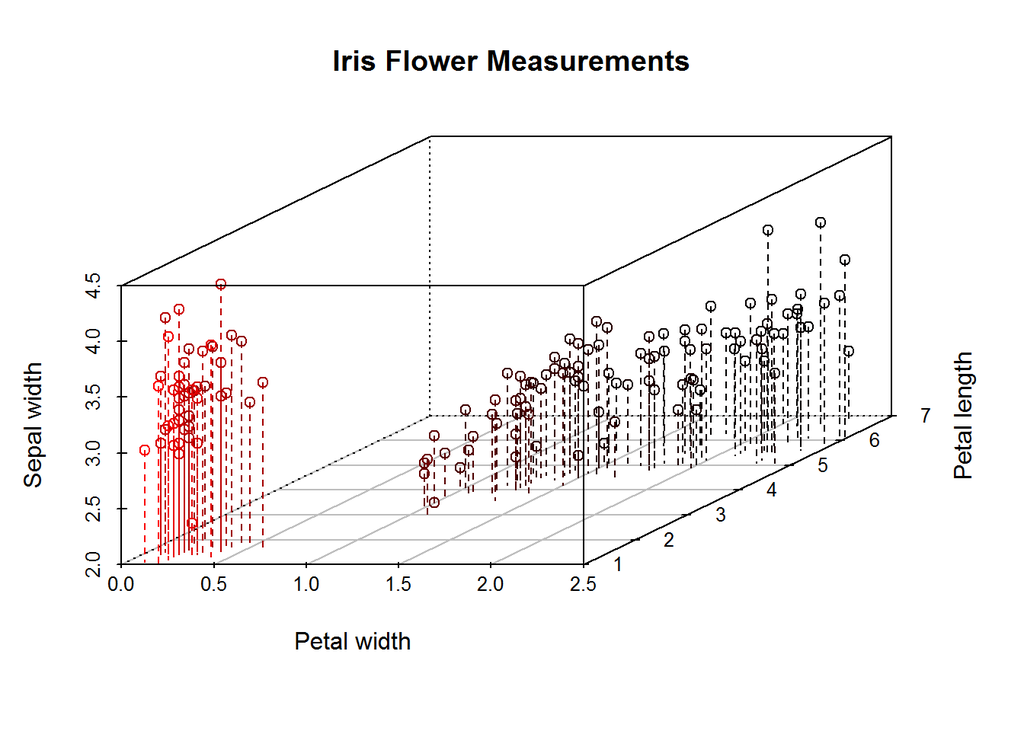

```r
scatterplot3d(x=pwid, y=plen, z=swid, highlight.3d=TRUE, type="h",
              lty.hplot=2, lty.hid=3, xlab="Petal width", ylab="Petal length",
              zlab="Sepal width", main="Iris Flower Measurements")
```

In the plot above, `highlight.3d=TRUE` instructs the function to apply color transitioning from red to black as an indicator of depth (distance along the y-axis). The `lty.hplot` parameter is the type of the ‘height-lines’ (in this case 2 i.e. dashed), while `lty.hid` is the type of line used for the hidden lines of the box (in this case 3 i.e. dotted).

Finally, we plot the iris set including a colour palette for the fourth variable (sepal length) and using different point shapes for the different species of iris.

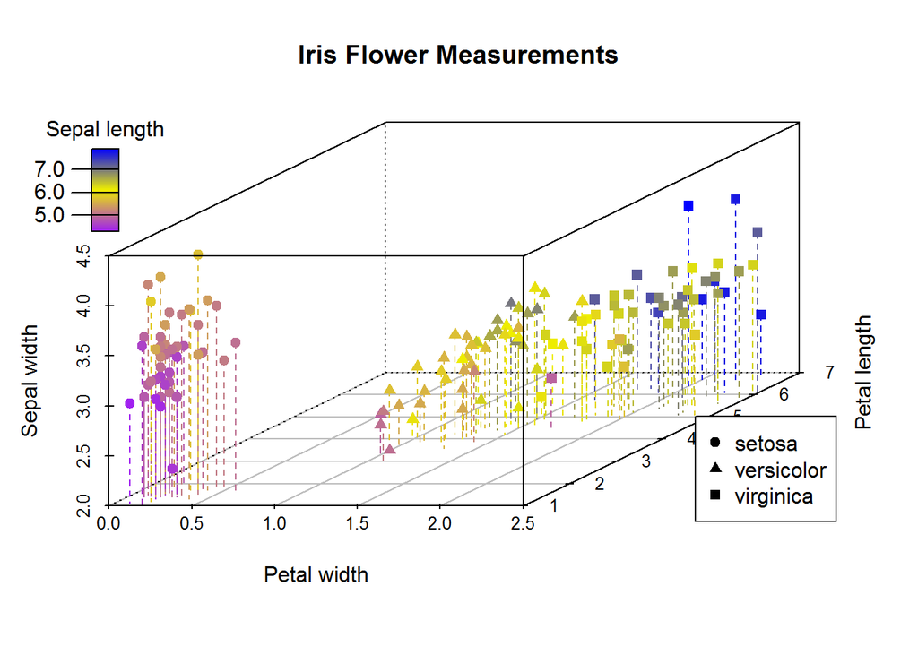

```r
keycols <- c("purple", "yellow2", "blue")
slen.pal <- colorRampPalette(keycols)
slen.pal2 <- colorRamp(keycols)
slen.cols <- rgb(slen.pal2(normalize(slen)), maxColorValue=255)

scatterplot3d(x=pwid, y=plen, z=swid, color=slen.cols,
              pch=c(19, 17, 15)[as.numeric(iris$Species)], type="h",
              lty.hplot=2, lty.hide=3, xlab="Petal width",
              ylab="Petal length", zlab="Sepal width",
              main="Iris Flower Measurements")
legend("bottomright", legend=levels(iris$Species), pch=c(19, 17, 15))
colorlegend(slen.pal(200), zlim=range(slen), zval=5:7, digit=1,
            posx=c(0.1, 0.13), posy=c(0.7, 0.9), left=TRUE, main="Sepal length")
```

## Bivariate surface plotting

A bivariate surface is formed by the values of a continuous dependent variable as a function of two continuous independent variables. As plotting a truly continuous surface is impossible in practice, a finite 2D grid of evenly spaced coordinates on the independent variable axes (the evaluation grid) is used for plotting such functions. The matrix of function values corresponding to these grid points is called the **z-matrix**.

Let’s construct an evaluation grid:

```r
xcoords <- 1:6
ycoords <- 1:4
xycoords <- expand.grid(x=xcoords, y=ycoords)
xycoords
```

```
##    x y
## 1  1 1
## 2  2 1
## 3  3 1
## 4  4 1
## 5  5 1
## 6  6 1
## 7  1 2
## 8  2 2
## 9  3 2
## 10 4 2
## 11 5 2
## 12 6 2
## 13 1 3
## 14 2 3
## 15 3 3
## 16 4 3
## 17 5 3
## 18 6 3
## 19 1 4
## 20 2 4
## 21 3 4
## 22 4 4
## 23 5 4
## 24 6 4
```

The following code shows the first 24 letters of the alphabet (in order) matched with the coordinates created earlier ordered by column-wise traversal of a matrix with x representing rows and y representing columns.

```r
z <- letters[1:24]
cbind(xycoords, z)
```

```
##    x y z
## 1  1 1 a
## 2  2 1 b
## 3  3 1 c
## 4  4 1 d
## 5  5 1 e
## 6  6 1 f
## 7  1 2 g
## 8  2 2 h
## 9  3 2 i
## 10 4 2 j
## 11 5 2 k
## 12 6 2 l
## 13 1 3 m
## 14 2 3 n
## 15 3 3 o
## 16 4 3 p
## 17 5 3 q
## 18 6 3 r
## 19 1 4 s
## 20 2 4 t
## 21 3 4 u
## 22 4 4 v
## 23 5 4 w
## 24 6 4 x
```

The z-values can be placed into a matrix by just passing in the vector `z`.

```r
nx <- length(xcoords)
ny <- length(ycoords)
zmat <- matrix(z, nrow=nx, ncol=ny)
zmat
```

```
##      [,1] [,2] [,3] [,4]
## [1,] "a"  "g"  "m"  "s"
## [2,] "b"  "h"  "n"  "t"
## [3,] "c"  "i"  "o"  "u"
## [4,] "d"  "j"  "p"  "v"
## [5,] "e"  "k"  "q"  "w"
## [6,] "f"  "l"  "r"  "x"
```

### Contour plots

```r
dim(volcano)
```

```
## [1] 87 61
```

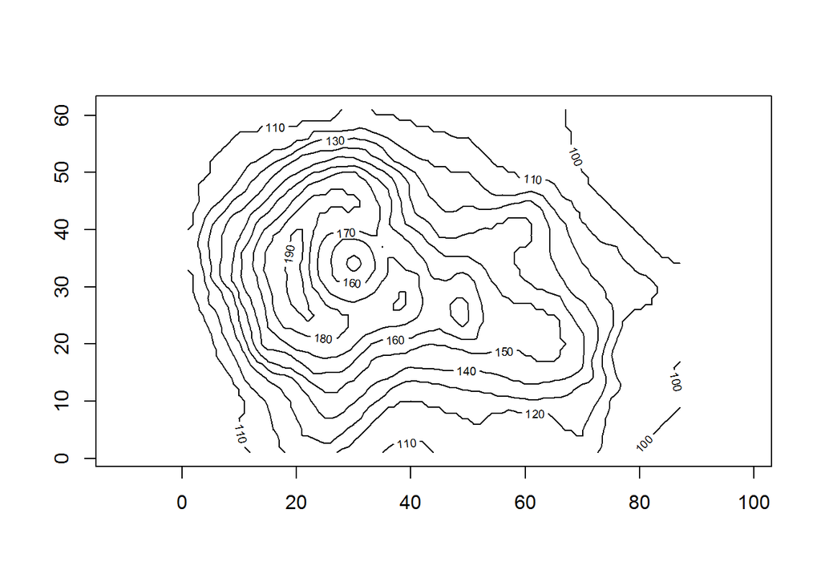

```r
contour(x=1:nrow(volcano), y=1:ncol(volcano), z=volcano, asp=1)
```

The second example is of a **parametric response surface**. This is the surface formed by values predicted from two independent variables by a parametric model. Let’s use the `mtcars` dataset to model the miles-per-galon values based on horsepower and weight.

```r
car.fit <- lm(mpg~hp*wt, data=mtcars)
car.fit
```

```
##
## Call:
## lm(formula = mpg ~ hp * wt, data = mtcars)
##
## Coefficients:
## (Intercept)           hp           wt        hp:wt
##    49.80842     -0.12010     -8.21662      0.02785
```

We decide on 20 points on each axis for prediction and set up the grid to cover the ranges for `mtcars$hp` and `mtcars$wt`.

```r
len <- 20
hp.seq <- seq(min(mtcars$hp), max(mtcars$hp), length=len)
wt.seq <- seq(min(mtcars$wt), max(mtcars$wt), length=len)
hp.wt <-expand.grid(hp=hp.seq, wt=wt.seq)
```

Now we apply the model to the points in the matrix, then place the vector of results into a z-matrix.

```r
car.pred <- predict(car.fit, newdata=hp.wt)
car.pred.mat <- matrix(car.pred, nrow=len, ncol=len)
```

Finally, we can plot the contour plot, showing the lines of constant predicted values for the model.

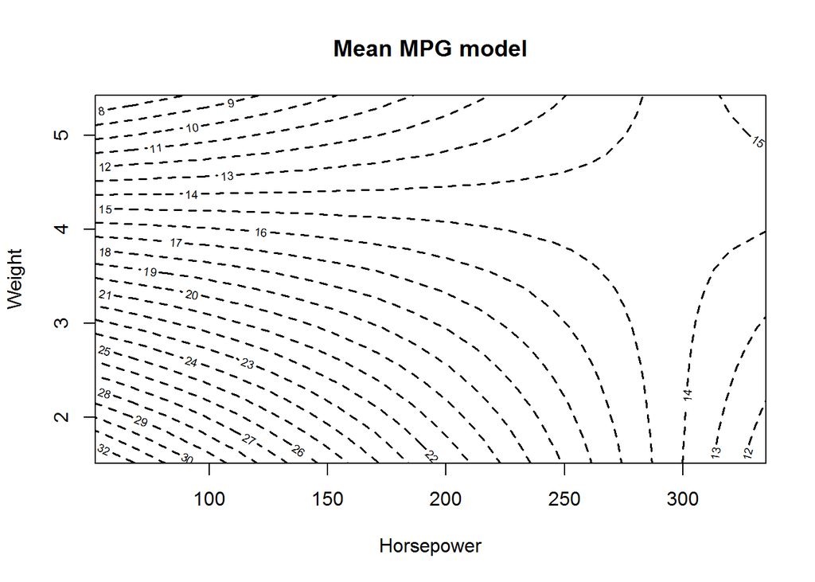

```r
contour(x=hp.seq, y=wt.seq, z=car.pred.mat, levels=32:8, lty=2, lwd=1.5,
        xaxs="i", yaxs="i", xlab="Horsepower", ylab="Weight",
        main="Mean MPG model")
```